# project-2-report

Marilyn McCarthy

2025-10-23

# **Introduction**

Type 1 diabetes (T1D) is an autoimmune disease in which the immune system targets and destroys insulin-producing β-cells in the pancreas. Genetic studies have identified over 120 non-HLA regions associated with T1D susceptibility, including the TYK2 gene, which encodes a member of the Janus kinase (JAK) family involved in cytokine-mediated STAT signaling. TYK2 regulates immune pathways such as type I interferon responses, and alterations in its expression or function can influence β-cell survival and autoimmune activity. This study investigates the role of TYK2 in pancreatic lineage differentiation using RNA sequencing (RNA-seq) data from wild-type (WT) and TYK2 knockout (KO) cells. The full dataset includes samples from multiple stages of differentiation: stem cells (hiPSCs), pancreatic progenitors (S4), endocrine progenitors (S5), and immature islets (S6). This analysis specifically focuses on the S5 stage, comparing WT and TYK2 KO cells, to examine the effects of TYK2 loss during the transition to endocrine progenitors. Transcriptomic analysis is employed to identify changes in gene expression and pathway activity associated with TYK2 KO, providing insight into its role in pancreatic development and potential implications for T1D.

# **Methods**

### **Source of Data**

Paired-end mRNA-seq reads were obtained from `/projectnb/bf528/materials/project-2-rnaseq/full_files/*_{R1,R2}.fastq.gz`. The human reference genome (GRCh38.primary_assembly.genome.fa) and the corresponding annotation file (GENCODE v45, gencode.v45.primary_assembly.annotation.gtf) were used for alignment and quantification.

### **Workflow Management**

All analyses were executed using Nextflow v25.04.6.5954 to ensure reproducibility, modularity, and parallelization of each process.

### **Quality Control**

Initial quality assessment of raw reads was performed using FastQC v0.12.1 with default parameters. The `-t` option was used to utilize all available CPUs per task. FastQC generated `.html` and `.zip` reports for each sample. Summary metrics from all samples and STAR alignment logs were aggregated using MultiQC v1.25 with default parameters, producing a combined report (`multiqc_report.html`) that provided an overview of read quality and alignment statistics.

### **Genome Indexing**

A genome index was generated using STAR v2.7.11b from the GRCh38 reference genome and the GENCODE v45 annotation. This index was used to facilitate accurate and efficient alignment of sequencing reads in downstream analysis. Default parameters were used for all indexing steps.

### **Annotation Parsing**

Gene identifiers and names were extracted from the GENCODE v45 GTF file using a custom Python script (`parse_gtf.py`) executed with Python v1.84. The script parsed `gene_id` and `gene_name` fields using regular expressions and output a tab-delimited mapping file (`id2name.txt`) for downstream use.

### **Read Alignment**

Reads were aligned to the indexed GRCh38 genome using STAR v2.7.11b. Input included the pre-built genome index and paired FASTQ files. Alignment was performed with threading, compressed input handling, and output as coordinate-sorted BAM files. Alignment logs were captured for downstream analysis.

### **Read Quantification**

Exon-level read counts were generated from aligned BAM files using VERSE v0.1.5. Strand-specific counting was enabled with the `-S` flag. The GENCODE v45 GTF file was used as the annotation reference. For each sample, VERSE produced a tab-delimited exon count file (`[sample_id].exon.txt`).

### **Data Integration**

All exon count files were combined into a single counts matrix using a custom Python script (`concat.py`) executed with Python v1.84 and Pandas v2.2.3. The script merged all `.exon.txt` files on gene identifiers, producing `counts_matrix.csv` with genes as rows and samples as columns. Missing values were filled with zeros. This counts matrix was used for downstream normalization and differential expression analysis.

# **Results**

### **Quality Control Evaluation**

Sequencing reads across all samples ranged from 84.5 million to 118.9 million, with an average of approximately 103 million reads per sample. STAR alignment rates to the GRCh38 reference genome were high for all samples, ranging from 95.8% to 97.8%, with unique alignment rates between 91.9% and 94.0%, indicating excellent mapping efficiency. FASTQC analysis revealed that all samples passed mean sequence quality, per-sequence quality, per-sequence GC content, per-base N content, and sequence length distribution. Some issues were observed for per-base sequence content, with 6 of 12 sequences flagged with warnings and 6 failing, and all samples failed sequence duplication level metrics. Overrepresented sequences were detected in half of the samples, although these sequences accounted for a very small fraction of reads (maximum ~0.017%). No adapter contamination was detected in any sample.

Overall, the high read counts, strong alignment rates, and generally clean quality metrics suggest that the dataset is of high quality and suitable for downstream analysis. Minor issues with sequence content and duplication levels are not expected to significantly impact the results; however, if necessary, further trimming or removal of duplicated reads could be performed to improve data quality.

### **Filtering the counts matrix**

To remove lowly expressed genes that could contribute noise to downstream analyses, the counts matrix was filtered to retain only genes with counts ≥ 10 in all samples. This threshold ensured that only genes with sufficient expression across all six samples were kept for analysis. Before filtering, the counts matrix contained 63,241 genes, and after applying the filter, 18,513 genes remained. **Figure 1** shows a barplot illustrating the effect of filtering on the number of genes, highlighting the substantial reduction in lowly expressed genes. **Figure 2** presents the distribution of gene counts across all samples, log₁₀-transformed to account for skew. Before filtering, the majority of genes had very low read counts, resulting in a high density near zero, whereas after filtering, this low-count peak was removed, leaving a distribution enriched for genes with moderate to high expression levels. Together, these figures demonstrate that the filtering step effectively removes genes with minimal expression, improving the robustness and reliability of downstream differential expression analyses by focusing on biologically meaningful genes.

```r
library(DESeq2)
library(tidyverse)
```

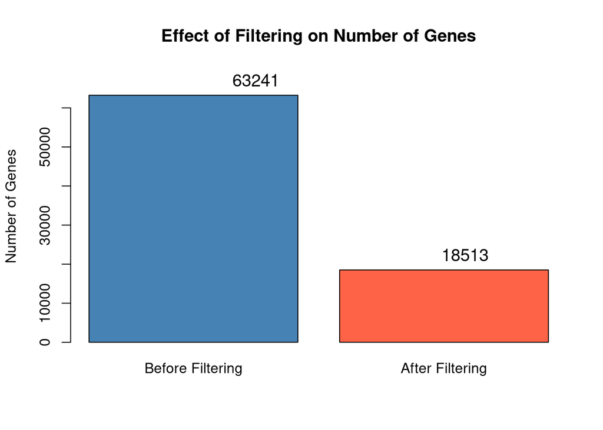

```r
cts <- as.matrix(read.csv("results/counts_matrix.csv", row.names='gene'))
# Apply filter: keep genes with counts >= 10 in all samples
keep_genes <- rowSums(cts >= 10) >= 6
filtered_counts <- cts[keep_genes, ]
# Number of genes before and after filtering
num_before <- nrow(cts)
num_after <- nrow(filtered_counts)

# Create a named vector for the barplot
genes_kept <- c("Before Filtering" = num_before, "After Filtering" = num_after)

# Simple barplot
barplot(genes_kept,
        col = c("steelblue", "tomato"),
        main = "Effect of Filtering on Number of Genes",
        ylab = "Number of Genes",
        ylim = c(0, max(genes_kept) * 1.1))

# Add text labels on top of bars
text(x = 1:length(genes_kept),
     y = genes_kept,
     label = genes_kept,
     pos = 3, cex = 1.2, col = "black")
```

**Figure 1.** Barplot showing the number of genes before and after filtering for counts ≥ 10 in all samples, reducing the dataset from 63,241 to 18,513 genes.

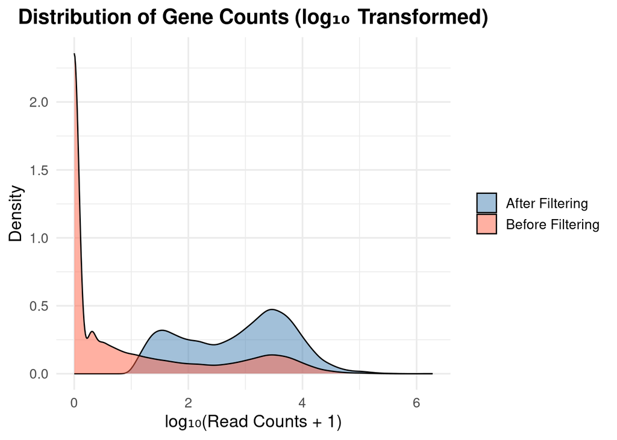

```r
# Flatten counts to a vector (all genes across all samples)
cts_all <- as.vector(cts)
filtered_all <- as.vector(filtered_counts)

# Combine into a data frame
combined <- data.frame(
  Count = c(cts_all, filtered_all),
  Filter = rep(c("Before Filtering", "After Filtering"),
               times = c(length(cts_all), length(filtered_all)))
)

# Add log10 transformation (to handle skew)
combined$logCount <- log10(combined$Count + 1)

# Density plot of gene counts
ggplot(combined, aes(x = logCount, fill = Filter)) +
  geom_density(alpha = 0.5) +
  labs(
    title = "Distribution of Gene Counts (log₁₀ Transformed)",
    x = "log₁₀(Read Counts + 1)",
    y = "Density"
  ) +
  scale_fill_manual(values = c("steelblue", "tomato")) +
  theme_minimal(base_size = 14) +
  theme(
    plot.title = element_text(hjust = 0.5, face = "bold"),
    legend.title = element_blank()
  )
```

**Figure 2.** Distribution of log₁₀-transformed read counts across all samples before and after filtering, illustrating the removal of lowly expressed genes and retention of moderately and highly expressed genes.

### Differential Expression Analysis

The set of significant genes was submitted to ENRICHR to identify enriched biological pathways and processes. The top pathways from the Reactome 2024 database included Extracellular Matrix Organization, Degradation of the Extracellular Matrix, Regulation of IGF Transport and Uptake by IGFBPs, Neuronal System, Post-translational Protein Phosphorylation, Regulation of Beta-Cell Development, and TP53 Transcriptional Gene Network. These results suggest that TYK2 knockout affects multiple cellular processes, including neuronal activity, extracellular matrix remodeling, growth factor signaling, and cell survival pathways.

Gene Set Enrichment Analysis (GSEA) using fgsea, with log₂ fold change as the ranking metric and a padj threshold of 0.05, identified significantly enriched pathways under TYK2 KO conditions. The most significant positively enriched pathway was REACTOME_NEURONAL_SYSTEM, and the most significant negatively enriched pathway was PID_P53_DOWNSTREAM_PATHWAY (**Table 2**). The enrichment plot for REACTOME_NEURONAL_SYSTEM (**Figure 3**) shows a rapid initial peak in the running enrichment score (ES), indicating that genes most strongly upregulated in this pathway are clustered near the top of the ranked gene list.

```r
coldata <- data.frame(
  sample = c("control_rep2", "exp_rep1", "control_rep1", "exp_rep2", "exp_rep3", "control_rep3"),
  condition = c("control", "exp", "control", "exp", "exp", "control")
)

# Set rownames as sample names to match count matrix columns
rownames(coldata) <- coldata$sample
coldata$sample <- NULL

#Perform DDS
dds <- DESeqDataSetFromMatrix(countData = filtered_counts,
                              colData = coldata,
                              design = ~ condition)
dds <- DESeq(dds)
res <- results(dds, contrast=c("condition","control","exp"))
resOrdered <- res[order(res$padj),]
deseq2_res <- as_tibble(resOrdered, rownames='gene')
id2name <- read_tsv(
  "results/id2name.txt",
  col_names = c("gene", "symbol")
)
deseq2_res <- deseq2_res %>%
  left_join(id2name) %>%
  relocate(symbol)
deseq2_res %>%
  head(10)
```

```
## # A tibble: 10 × 8
##    symbol         gene  baseMean log2FoldChange  lfcSE  stat    pvalue      padj
##    <chr>          <chr>    <dbl>          <dbl>  <dbl> <dbl>     <dbl>     <dbl>
##  1 RPS4Y1         ENSG…   10689.           8.77 0.140   62.7 0         0
##  2 ENSG000002895… ENSG…     733.          -3.70 0.123  -30.0 8.72e-198 7.75e-194
##  3 PNPO           ENSG…     605.           4.15 0.139   29.8 1.15e-195 6.83e-192
##  4 PCDHGA10       ENSG…     498.          -4.48 0.203  -22.1 2.25e-108 1.00e-104
##  5 YPEL3-DT       ENSG…     526.           2.42 0.113   21.4 2.71e-101 9.63e- 98
##  6 LINC02506      ENSG…    1303.           1.71 0.0968  17.7 6.12e- 70 1.81e- 66
##  7 SLC2A14        ENSG…     636.          -4.69 0.287  -16.4 4.20e- 60 1.07e- 56
##  8 ENSG000002863… ENSG…     908.           1.71 0.114   15.1 2.87e- 51 6.37e- 48
##  9 ENSG000002894… ENSG…     384.           2.13 0.145   14.7 8.63e- 49 1.71e- 45
## 10 ENSG000002829… ENSG…     121.          -3.76 0.265  -14.2 1.29e- 45 2.30e- 42
```

**Table 1.** Table of the top 10 differentially expressed genes and the statistics provided by DESeq2 as ranked by adjusted p-value.

```r
library(fgsea)
# Make sure there are no missing values and symbols are unique
deseq2_res_ordered <- deseq2_res %>%
  drop_na(symbol, log2FoldChange) %>%
  distinct(symbol, .keep_all = TRUE)

deseq2_res_ranked <- deseq2_res_ordered %>%
  arrange(desc(log2FoldChange))

ranked_list <- setNames(deseq2_res_ranked$log2FoldChange, deseq2_res_ranked$symbol)
pathways <- gmtPathways("c2.cp.v2025.1.Hs.symbols.gmt")
fgseaRes <- fgsea(pathways, ranked_list, minSize=15, maxSize=500)

fgsea_sig <- fgseaRes %>%
  arrange(padj) %>%
  filter(padj < 0.05)

head(fgsea_sig)
```

```
##                                           pathway         pval         padj
##                                            <char>        <num>        <num>
## 1:                       REACTOME_NEURONAL_SYSTEM 1.421396e-12 3.318959e-09
## 2:                     PID_P53_DOWNSTREAM_PATHWAY 1.081271e-10 1.262384e-07
## 3:                WP_ADHD_AND_AUTISM_ASD_PATHWAYS 1.189404e-08 9.257527e-06
## 4:                     REACTOME_SIGNALING_BY_GPCR 8.450032e-08 4.932706e-05
## 5:     REACTOME_EXTRACELLULAR_MATRIX_ORGANIZATION 1.301613e-07 6.078531e-05
## 6: REACTOME_TRANSMISSION_ACROSS_CHEMICAL_SYNAPSES 1.066928e-06 3.558968e-04
##      log2err         ES       NES  size  leadingEdge
##        <num>      <num>     <num> <int>       <list>
## 1: 0.9101197  0.5409162  2.027235   337 SLITRK2,....
## 2: 0.8390889 -0.6335688 -2.335819   132 SPP1, HG....
## 3: 0.7477397  0.5163948  1.925647   304 PNPO, CN....
## 4: 0.7049757  0.4568255  1.746193   439 GAST, GC....
## 5: 0.6901325 -0.4645737 -1.846094   268 MMP12, C....
## 6: 0.6435518  0.4996741  1.804586   218 DLG2, GN....
```

**Table 2.** Top significantly enriched pathways identified by GSEA (padj < 0.05). Normalized enrichment scores (NES) indicate whether a pathway is upregulated (positive) or downregulated (negative).

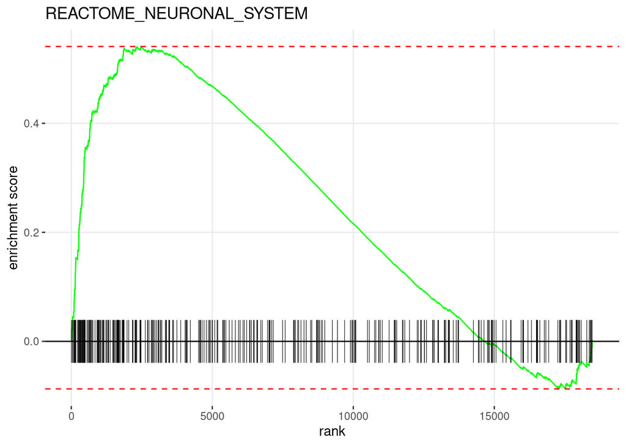

```r
plotEnrichment(pathways[["REACTOME_NEURONAL_SYSTEM"]],
               ranked_list) + labs(title="REACTOME_NEURONAL_SYSTEM")
```

**Figure 3.** GSEA enrichment plot for the REACTOME_NEURONAL_SYSTEM pathway.

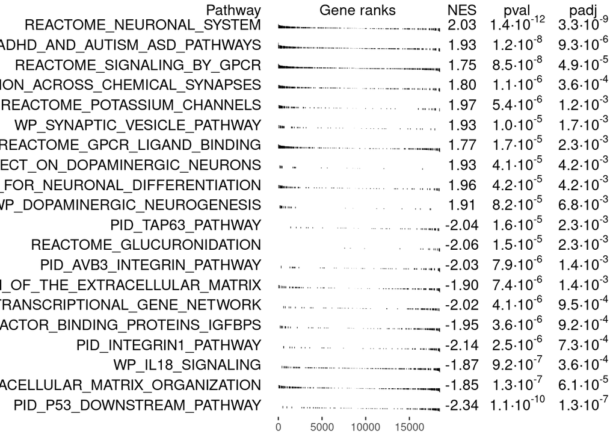

```r
topPathwaysUp <- fgseaRes[ES > 0][head(order(pval), n=10), pathway]
topPathwaysDown <- fgseaRes[ES < 0][head(order(pval), n=10), pathway]
topPathways <- c(topPathwaysUp, rev(topPathwaysDown))
plotGseaTable(pathways[topPathways], ranked_list, fgseaRes,
              gseaParam=0.5)
```

**Figure 4.** GSEA plot showing the top 10 upregulated and downregulated pathways.

### RNA Seq Quality Control

Both the PCA plot and the sample-to-sample distance heatmap provide insight into the quality and reliability of the RNA-seq experiment. In the PCA plot, control replicates cluster tightly on the lower left, while two experimental replicates (exp_1 and exp_2) cluster on the lower right, indicating that the primary source of variation is the experimental condition. The third experimental replicate (exp_3) is positioned between the other experimental samples and the controls, suggesting intermediate gene expression patterns. This behavior may reflect biological variability, a partial response to treatment, or minor technical differences. The sample-to-sample distance heatmap supports the observation that most replicates show high similarity along the diagonal (dark blue), while exp_3 appears slightly more similar to the controls than to the other experimental replicates, reinforcing the PCA result. Overall, these analyses indicate that the dataset is reliable and largely captures the expected experimental effects, though some variability should be considered in downstream interpretation.

```r
library(DESeq2)
library(ggplot2)
library(ggrepel)
vsd <- vst(dds, blind=FALSE)
# Calculate PCA coordinates
pcaData <- plotPCA(vsd, intgroup = "condition", returnData = TRUE)
```

```
## using ntop=500 top features by variance
```

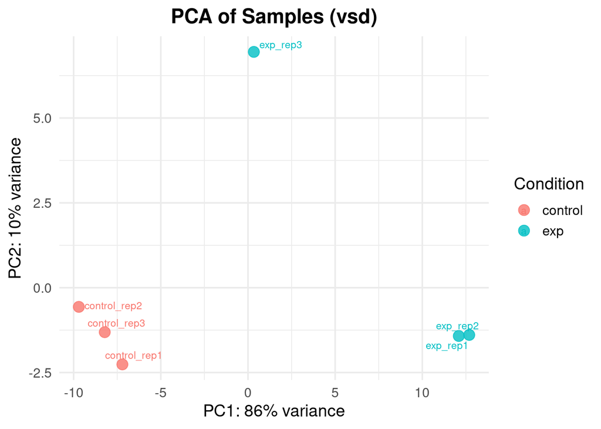

```r
percentVar <- round(100 * attr(pcaData, "percentVar"))

ggplot(pcaData, aes(x = PC1, y = PC2, color = condition, label = name)) +
  geom_point(size = 4, alpha = 0.8) +               # points
  geom_text_repel(size = 3, max.overlaps = 10) +    # sample labels
  labs(
    x = paste0("PC1: ", percentVar[1], "% variance"),
    y = paste0("PC2: ", percentVar[2], "% variance"),
    title = "PCA of Samples (vsd)",
    color = "Condition"
  ) +
  theme_minimal(base_size = 14) +
  theme(
    plot.title = element_text(hjust = 0.5, face = "bold"),
    legend.position = "right"
  )
```

**Figure 5.** Variance-stabilized counts were used to perform principal component analysis (PCA).

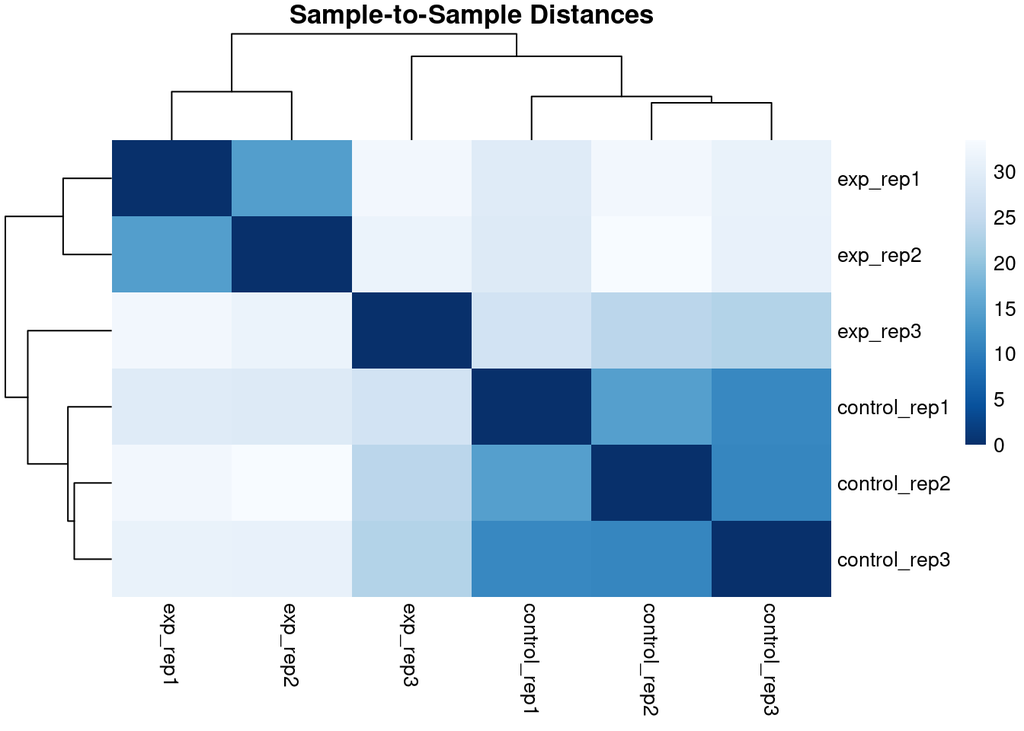

```r
library(pheatmap)
library(RColorBrewer)

# 1. Compute distances between samples
sampleDists <- dist(t(assay(vsd)))

# 2. Compute hierarchical clustering
hc <- hclust(sampleDists, method = "average")

# 3. Convert to matrix for plotting
sampleDistMatrix <- as.matrix(sampleDists)
rownames(sampleDistMatrix) <- colnames(vsd)
colnames(sampleDistMatrix) <- colnames(vsd)

# 4. Define colors
colors <- colorRampPalette(rev(brewer.pal(9, "Blues")))(255)

# 5. Plot with precomputed clustering
pheatmap(
  sampleDistMatrix,
  cluster_rows = hc,
  cluster_cols = hc,
  col = colors,
  main = "Sample-to-Sample Distances",
  fontsize_row = 10,
  fontsize_col = 10,
  border_color = NA
)
```

**Figure 6.** Sample-to-sample distance heatmap. Pairwise Euclidean distances were calculated from variance-stabilized counts, and hierarchical clustering was performed using the average linkage method.

### Replicate Figure 3C and 3F

Comparison of enrichment results between the original study and the present analysis shows substantial overlap in affected pathways, including neuronal system, extracellular matrix organization, and p53-related processes. Some differences in pathway ranking and significance likely reflect the use of only the S5 timepoint and the methodological differences noted above. Overall, these figures demonstrate that the differential expression patterns and pathway-level impacts observed in this analysis are broadly consistent with the original findings, while highlighting specific nuances introduced by focusing on a single developmental stage.

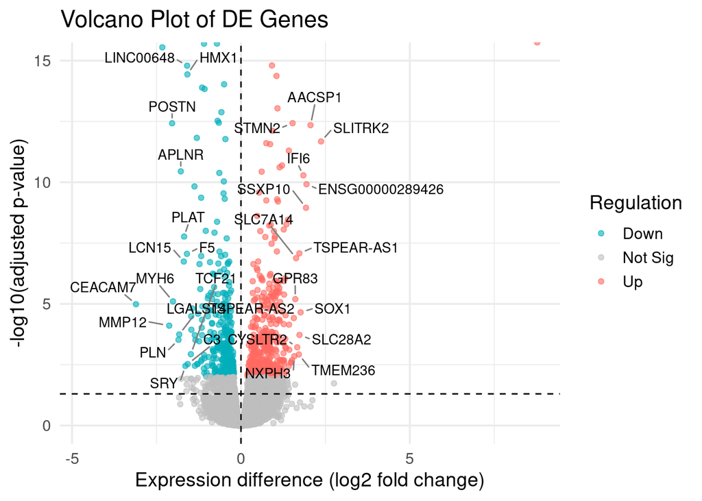

```r
volcano_data <- deseq2_res %>%
  drop_na(log2FoldChange, padj, symbol) %>%
  mutate(
    negLog10Padj = -log10(padj),
    regulation = case_when(
      padj < 0.01 & log2FoldChange > 0 ~ "Up",
      padj < 0.01 & log2FoldChange < 0 ~ "Down",
      TRUE ~ "Not Sig"
    )
  )

top_up <- volcano_data %>%
  filter(regulation == "Up") %>%
  arrange(padj) %>%
  slice_head(n = 10)

top_down <- volcano_data %>%
  filter(regulation == "Down") %>%
  arrange(padj) %>%
  slice_head(n = 10)

top_genes <- bind_rows(top_up, top_down)

sig_genes <- volcano_data %>%
  filter(regulation != "Not Sig", negLog10Padj <= 15)

# Top 15 upregulated by log2FC
top_up <- sig_genes %>%
  filter(regulation == "Up") %>%
  arrange(desc(log2FoldChange)) %>%
  slice_head(n = 15)

# Top 5 downregulated by log2FC
top_down <- sig_genes %>%
  filter(regulation == "Down") %>%
  arrange(log2FoldChange) %>%  # most negative first
  slice_head(n = 15)

# Combine top genes
top_genes <- bind_rows(top_up, top_down)

ggplot(volcano_data, aes(x = log2FoldChange, y = negLog10Padj)) +
  geom_point(aes(color = regulation), alpha = 0.6, size = 1.5) +
  geom_vline(xintercept = 0, linetype = "dashed", color = "black") +
  geom_hline(yintercept = -log10(0.05), linetype = "dashed", color = "black") +
  geom_text_repel(
    data = top_genes,
    aes(label = symbol),
    size = 3.5,
    max.overlaps = Inf,
    box.padding = 0.5,
    point.padding = 0.5,
    segment.color = 'grey50',
    segment.size = 0.5,
    nudge_y = 0.5,
    min.segment.length = 0
  ) +
  scale_color_manual(values = c("Up" = "#FF6961", "Down" = "#00AFBB", "Not Sig" = "gray")) +
  labs(
    x = "Expression difference (log2 fold change)",
    y = "-log10(adjusted p-value)",
    color = "Regulation",
    title = "Volcano Plot of DE Genes"
  ) +
  coord_cartesian(ylim = c(0, 15)) +
  theme_minimal(base_size = 14)
```

**Figure 7.** Volcano plot of differentially expressed genes.

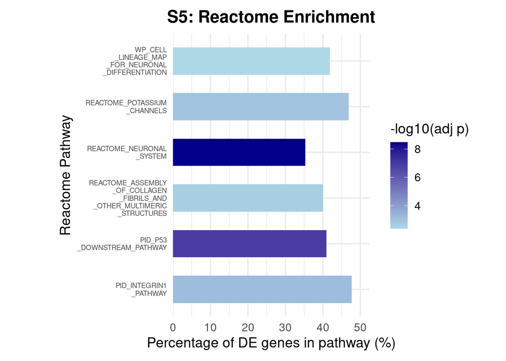

```r
# Compute percent DE genes
fgsea_sig <- fgsea_sig %>%
  mutate(
    percent_DE = 100 * sapply(leadingEdge, length) / size
  )

# Select top pathways: 3 upregulated and 3 downregulated by NES
top_up <- fgsea_sig %>%
  arrange(desc(NES)) %>%
  slice_head(n = 3)

top_down <- fgsea_sig %>%
  arrange(NES) %>%
  slice_head(n = 3)

# Combine selected pathways
plot_df <- bind_rows(top_up, top_down)

# Wrap long pathway names
plot_df$pathway <- str_wrap(plot_df$pathway, width = 30)

# Order pathways for plotting
plot_df <- plot_df %>%
  arrange(percent_DE) %>%
  mutate(pathway = factor(pathway, levels = pathway))


plot_df$pathway <- as.character(plot_df$pathway)

split_every_second_underscore <- function(x) {
  # Find positions of all underscores
  underscores <- str_locate_all(x, fixed("_"))[[1]][, "start"]

  if(length(underscores) < 2) {
    return(x)  # no split if less than 2 underscores
  }

  # We want to insert line breaks after every 2nd underscore:
  # Find positions after which to insert newline
  breaks <- underscores[seq(2, length(underscores), by = 2)]

  # Start building new string by splitting at these positions
  prev_pos <- 1
  parts <- c()
  for(pos in breaks) {
    parts <- c(parts, substr(x, prev_pos, pos - 1))
    prev_pos <- pos
  }
  # Add remaining part
  parts <- c(parts, substr(x, prev_pos, nchar(x)))

  # Join parts with newline
  paste(parts, collapse = "\n")
}

# Apply to all pathway names
plot_df$pathway <- sapply(plot_df$pathway, split_every_second_underscore)
# Plot
ggplot(plot_df, aes(x = percent_DE, y = pathway, fill = -log10(padj))) +
  geom_col(width = 0.6) +
  scale_fill_gradient(low = "lightblue", high = "darkblue", name = "-log10(adj p)") +
  labs(
    x = "Percentage of DE genes in pathway (%)",
    y = "Reactome Pathway",
    title = "S5: Reactome Enrichment"
  ) +
  theme_minimal(base_size = 14) +
  theme(
    plot.title = element_text(hjust = 0.5, face = "bold"),
    axis.text.y = element_text(size = 7),            # make y-axis text smaller
    plot.margin = margin(t = 10, r = 30, b = 10, l = 60)  # extra left margin for y text
  ) +
  scale_x_continuous(expand = expansion(mult = c(0, 0.1)))  # opt: add space at right for labels on bars if any
```